# Differential Expression Volcano Plot Analysis

## Print panels

```r
# Load lipid volcano (2-panel version)
lipid_volcano_2_file <- file.path(paths$intermediate, "lipid_volcano_2_TIC.rds")
if (file.exists(lipid_volcano_2_file)) {
  lipid_volcano_2 <- readRDS(lipid_volcano_2_file)
  cat("Loaded lipid volcano 2-panel plot\n")
} else {
  warning("Lipid volcano 2-panel plot not found. Run differential_lipid_analysis_leaf_treatment_interaction_model.Rmd first.")
}
```

```
## Loaded lipid volcano 2-panel plot
```

```r
# Load transcript MDS (reuse if already loaded)
if (!exists("p_transcript_MDS")) {
  transcript_MDS_file <- file.path(paths$intermediate, "transcript_MDS_12.rds")
  if (file.exists(transcript_MDS_file)) {
    p_transcript_MDS <- readRDS(transcript_MDS_file)
    cat("Loaded transcript MDS plot\n")
  } else {
    warning("Transcript MDS plot not found. Run differential_expression_leaf_treatment_model.Rmd first.")
  }
}

if (!exists("p_lipid_MDS")) {
  lipid_MDS_file <- file.path(paths$intermediate, "lipid_MDS_23.rds")
  if (file.exists(lipid_MDS_file)) {
    p_lipid_MDS <- readRDS(lipid_MDS_file)
    cat("Loaded lipid MDS plot\n")
  } else {
    warning("Lipid MDS plot not found. Run differential_lipid_analysis_leaf_treatment_interaction_model.Rmd first.")
  }
}

lipid_trajectory_file <- file.path(paths$intermediate, "lipid_trajectory_6panel.rds")
if (file.exists(lipid_trajectory_file)) {
  p_lipid_examples <- readRDS(lipid_trajectory_file)
  cat("Loaded lipid trajectory 6-panel plot\n")
} else {
  warning("Lipid trajectory plot not found. Run differential_lipid_analysis_leaf_treatment_interaction_model.Rmd first.")
}
```

```
## Loaded lipid trajectory 6-panel plot
```

```r
# Only create panels if all required plots exist
if (exists("p_transcript_MDS") && exists("volcano_2panel")) {
  top_panel   <- cowplot::plot_grid(
    p_transcript_MDS +  theme(plot.margin = margin(l=5.5,r=-15, b=-5, "pt")),
    volcano_2panel + ggpubr::rremove("xlab"),
    nrow=1,
    ncol=2,
    rel_widths = c(1,2),
    align = "h",
    axis = "tb",
    common.legend = TRUE,
    legend = "left")

  ggsave(
    filename = file.path(paths$figures, "top_panel.png"),
    plot = top_panel,
    height = 6,
    width = 18,
    units = "in",
    dpi = 150
  )
  cat("Figure saved: top_panel.png (18 x 6 inches @ 150 dpi)\n")
} else {
  cat("Skipping top panel - required plots not available.\n")
}
```

```
## Figure saved: top_panel.png (18 x 6 inches @ 150 dpi)
```

```r
if (exists("p_lipid_MDS") && exists("lipid_volcano_2")) {
  bottom_panel   <- cowplot::plot_grid(
    p_lipid_MDS +  theme(plot.margin = margin(l=5.5,r=-15, "pt")),
    lipid_volcano_2 + ggpubr::rremove("xlab"),
    nrow=1,
    ncol=2,
    rel_widths = c(1,2),
    align = "h",
    axis = "tb",
    common.legend = TRUE,
    legend = "left")

  ggsave(
    filename = file.path(paths$figures, "bottom_panel.png"),
    plot = bottom_panel,
    height = 6,
    width = 18,
    units = "in",
    dpi = 150
  )
  cat("Figure saved: bottom_panel.png (18 x 6 inches @150 dpi)\n")
} else {
  cat("Skipping bottom panel - required plots not available. Run differential_lipid_analysis_leaf_treatment_interaction_model.Rmd first.\n")
}
```

```
## Figure saved: bottom_panel.png (18 x 6 inches @150 dpi)
```

```r
# The top and bottom panels don't look good on the knitted document
# So we print webpage-friendly versions for knitting
if (exists("volcano_2panel") && exists("lipid_volcano_2")) {
  compound_volcano_2<- ggpubr::ggarrange(
    volcano_2panel,
    lipid_volcano_2,
    ncol=1,
    align ="v"
  )
  print(compound_volcano_2)
} else {
  cat("Skipping compound_volcano_2 - lipid_volcano_2 not available.\n")
  if (exists("volcano_2panel")) {
    print(volcano_2panel)
  }
}
```

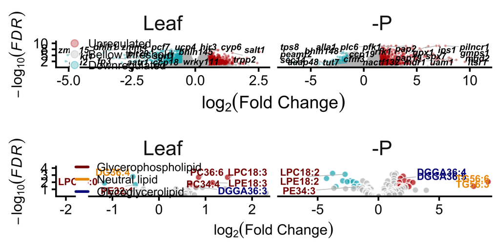

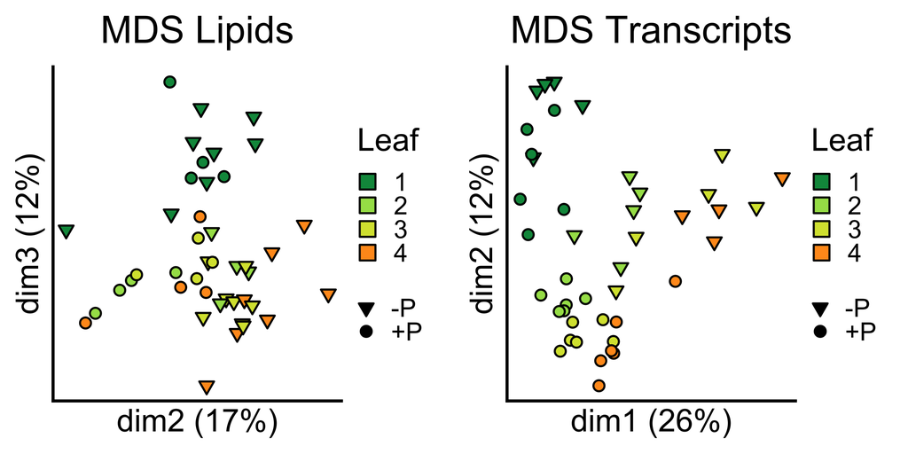

```r
if (exists("p_lipid_MDS") && exists("p_transcript_MDS")) {
  compound_MDS<- ggpubr::ggarrange(
    p_lipid_MDS,
    p_transcript_MDS,
    ncol=2,
    align ="hv")
  print(compound_MDS)
} else {
  cat("Skipping compound_MDS - required plots not available.\n")
}
```

## Single-Panel Volcano Plot (Leaf:-P only)

**Expected outcome**: Single-panel figure saved as high-resolution PNG.

```r
# Filter for Inv4m only
effects_1panel <- effects_df %>%
  filter(predictor == "Leaf:-P")

to_plot_1panel <- to_plot %>%
  filter(predictor == "Leaf:-P")

# Generate single-panel plot
volcano_1panel <- effects_1panel %>%
  ggplot(aes(x = logFC, y = neglogP, col = regulation)) +
  ylab(expression(-log[10](italic(FDR)))) +
  xlab(expression(log[2]("Fold Change"))) +
  scale_y_continuous(labels = scaleFUN, breaks=0:6) +
  geom_point(alpha = 0.3, size = 2) +
  geom_text_repel(
    data = to_plot_1panel,
    aes(label = locus_label),
    segment.color ="grey",
    force = 2,
    fontface = "bold.italic",
    size=6,
    color = "black",
    min.segment.length = 0,
    max.overlaps = 50,
    size = 7
  ) +
  scale_color_manual(
    name = "",
    values = c("#00AFBB", "grey", "#bb0c00"),
    labels = c("Negative", "Bellow threshold", "Positive")
  ) +
  guides(color = guide_legend(override.aes = list(size = 5))) +
  theme_classic2(base_size = 22) +
  theme(
    plot.title = element_blank(),
    legend.position = "top",
    legend.justification = "right",
    legend.background = element_rect(fill = "transparent"),
    legend.spacing = unit(0, "line"),
    legend.box.spacing = unit(0, "line"),
    legend.text = element_text(size = 20),
    legend.direction = "horizontal"
  )


ggsave(
  filename = file.path(paths$figures, "volcano_plot_LeafxP.png"),
  plot = volcano_1panel,
  height = 7,
  width = 7,
  units = "in",
  dpi = 150
)
cat("Figure saved: volcano_plot_LeafxP.png (7 x 7 inches @ 150 dpi)\n")
```

```
## Figure saved: volcano_plot_LeafxP.png (7 x 7 inches @ 150 dpi)
```

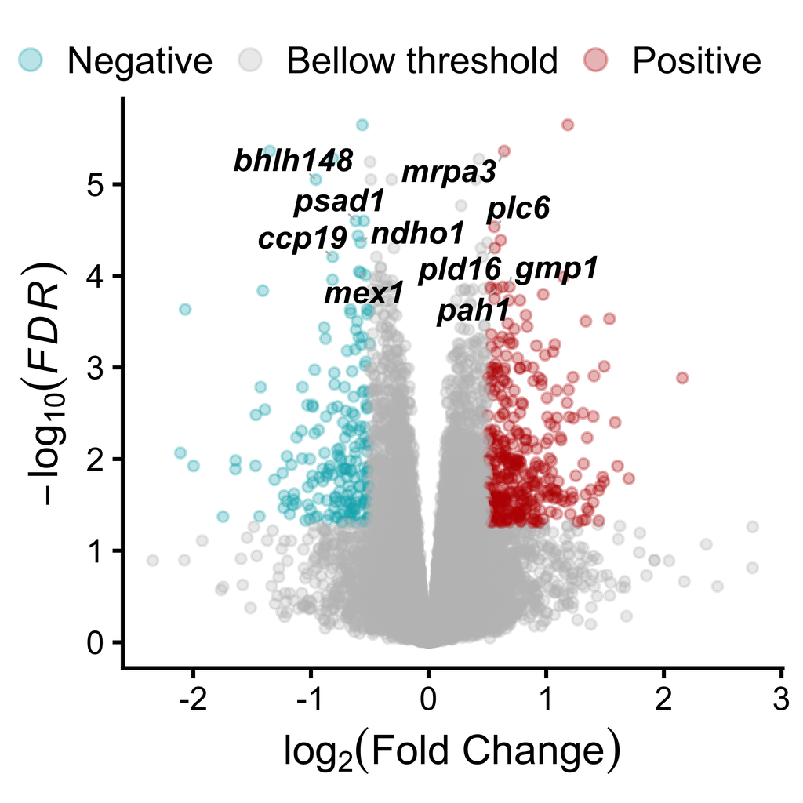

```r
print(volcano_1panel)
```

# Export Results

## Generate LaTeX Tables by Predictor × Regulation

**Purpose**: Create formatted tables of labeled genes for manuscript inclusion, split by predictor and regulation combination.

**Approach**: Subset to labeled genes, round numeric values, format for publication, and export separate LaTeX tables for each predictor × regulation combination.

**Expected outcome**: Multiple LaTeX table files organized by predictor and regulation direction.

```r
# Prepare table data
table_data <- curated %>%
  #filter(!is.na(locus_label) & locus_label != "") %>%
  group_by(predictor, regulation) %>%
  arrange(predictor, regulation, -neglogP) %>%
  mutate(
    logFC = round(logFC, digits = 2),
    neglogP = format(neglogP, digits = 2)
  ) %>%
  select(predictor, regulation, gene, locus_label, desc_merged, neglogP, logFC) %>%
  ungroup()

# Get unique predictor × regulation combinations
pred_reg_combinations <- table_data %>%
  distinct(predictor, regulation) %>%
  arrange(predictor, regulation)

# Generate separate LaTeX table for each combination
for (i in 1:nrow(pred_reg_combinations)) {
  pred <- pred_reg_combinations$predictor[i]
  reg <- pred_reg_combinations$regulation[i]

  # Filter data for this combination
  subset_data <- table_data %>%
    filter(predictor == pred, regulation == reg)

  # Create filename with sanitized predictor/regulation names
  pred_clean <- gsub(":", "_", pred)
  pred_clean <- gsub("-", "minus", pred_clean)
  reg_clean <- gsub(":", "_", reg)
  reg_clean <- gsub("-", "minus", reg_clean)

  filename <- file.path(paths$tables, paste0("DEG_table_", pred_clean, "_", reg_clean, ".tex"))

  # Generate LaTeX table
  subset_data %>%
    select(-predictor, -regulation) %>%
    kbl(
      caption = paste0(
        "Genes with ", tolower(reg), " expression in ", pred,
        " condition, selected by Mahalanobis distance"
      ),
      format = "latex",
      col.names = c("Gene", "Label", "Description", "-log10(FDR)", "logFC"),
      align = "lllrr",
      booktabs = TRUE
    ) %>%
    kable_classic(full_width = FALSE, latex_options = "HOLD_position") %>%
    save_kable(file = filename, format = "latex")

  cat("Saved:", filename, "(", nrow(subset_data), "genes )\n")
}
```

```
## Saved: /Users/fvrodriguez/Library/CloudStorage/GoogleDrive-frodrig4@ncsu.edu/My Drive/repos/inv4m/results/phosphorus_paper/tables/DEG_table_Leaf_Downregulated.tex ( 18 genes )
## Saved: /Users/fvrodriguez/Library/CloudStorage/GoogleDrive-frodrig4@ncsu.edu/My Drive/repos/inv4m/results/phosphorus_paper/tables/DEG_table_Leaf_Upregulated.tex ( 19 genes )
## Saved: /Users/fvrodriguez/Library/CloudStorage/GoogleDrive-frodrig4@ncsu.edu/My Drive/repos/inv4m/results/phosphorus_paper/tables/DEG_table_minusP_Downregulated.tex ( 17 genes )
## Saved: /Users/fvrodriguez/Library/CloudStorage/GoogleDrive-frodrig4@ncsu.edu/My Drive/repos/inv4m/results/phosphorus_paper/tables/DEG_table_minusP_Upregulated.tex ( 17 genes )
## Saved: /Users/fvrodriguez/Library/CloudStorage/GoogleDrive-frodrig4@ncsu.edu/My Drive/repos/inv4m/results/phosphorus_paper/tables/DEG_table_Leaf_minusP_Downregulated.tex ( 13 genes )
## Saved: /Users/fvrodriguez/Library/CloudStorage/GoogleDrive-frodrig4@ncsu.edu/My Drive/repos/inv4m/results/phosphorus_paper/tables/DEG_table_Leaf_minusP_Upregulated.tex ( 11 genes )
## Saved: /Users/fvrodriguez/Library/CloudStorage/GoogleDrive-frodrig4@ncsu.edu/My Drive/repos/inv4m/results/phosphorus_paper/tables/DEG_table_NA_Downregulated.tex ( 0 genes )
## Saved: /Users/fvrodriguez/Library/CloudStorage/GoogleDrive-frodrig4@ncsu.edu/My Drive/repos/inv4m/results/phosphorus_paper/tables/DEG_table_NA_Upregulated.tex ( 0 genes )
```

```r
# Also generate combined table with all genes
table_data %>%
  kbl(
    caption = paste(
      "All characterized genes selected by Mahalanobis distance outlier detection",
      "across predictors and regulation directions"
    ),
    format = "latex",
    col.names = c("Predictor", "Regulation", "Gene", "Label", "Description",
                  "-log10(FDR)", "logFC"),
    align = "llllrr",
    booktabs = TRUE
  ) %>%
  kable_classic(full_width = FALSE, latex_options = c("HOLD_position", "scale_down")) %>%
  collapse_rows(columns = 1:2, latex_hline = "major") %>%
  save_kable(file = file.path(paths$tables, "DEG_table_all_combined.tex"), format = "latex")

cat("\nSaved: DEG_table_all_combined.tex (", nrow(table_data), "genes total )\n")
```

```
##
## Saved: DEG_table_all_combined.tex ( 122 genes total )
```

## Display Table Previews by Predictor × Regulation

**Purpose**: Display HTML previews of tables for each predictor × regulation combination in the notebook.

```r
# Display separate tables for each combination
for (i in 1:nrow(pred_reg_combinations)) {
  pred <- pred_reg_combinations$predictor[i]
  reg <- pred_reg_combinations$regulation[i]

  # Filter data for this combination
  subset_data <- table_data %>%
    filter(predictor == pred, regulation == reg) %>%
    select(-predictor, -regulation)

  # Display header
  cat("\n\n### ", pred, " / ", reg, "\n\n")

  # Display table
  tbl <- subset_data %>%
    kbl(
      caption = paste0(nrow(subset_data), " genes"),
      col.names = c("Gene", "Label", "Description", "-log10(FDR)", "logFC")
    ) %>%
    kable_styling(
      bootstrap_options = c("striped", "hover", "condensed"),
      full_width = FALSE
    )

  print(tbl)
}
```

### 1 / Downregulated

18 genes

| Gene | Label | Description | -log10(FDR) | logFC |
| --- | --- | --- | --- | --- |
| Zm00001eb152840 | pcf7 | Transcription factor PCF7 | 7.5 | -1.48 |
| Zm00001eb151160 | NA | NTF2 domain-containing protein | 7.5 | -1.15 |
| Zm00001eb076680 | sgrl1 | Protein STAY-GREEN LIKE, chloroplastic | 7.5 | -0.95 |
| Zm00001eb038410 | ucp4 | Mitochondrial uncoupling protein 4 | 7.5 | -0.70 |
| Zm00001eb329970 | NA | Tyrosine-specific transport protein | 7.5 | -0.63 |
| Zm00001eb182020 | NA | protein MAINTENANCE OF PSII UNDER HIGH LIGHT 1 | 7.5 | -0.61 |
| Zm00001eb176730 | NA | photosynthetic NDH subunit of subcomplex B 1, chloroplastic | 7.5 | -0.52 |
| Zm00001eb391900 | NA | Short-chain dehydrogenase TIC 32, chloroplastic | 7.4 | -0.60 |
| Zm00001eb057540 | zmm4 | Zea mays MADS4 | 7.1 | -3.40 |
| Zm00001eb154820 | NA | Choline kinase | 7.1 | -0.53 |
| Zm00001eb016200 | bhlh1 | BHLH transcription factor | 6.0 | -3.62 |
| Zm00001eb364940 | plt29 | Lipid-transfer protein DIR1 | 5.2 | -2.80 |
| Zm00001eb214750 | zmm15 | Zea mays MADS-box 15 | 5.1 | -5.04 |
| Zm00001eb320160 | alkt1 | Alkyl transferase | 4.9 | -3.82 |
| Zm00001eb169010 | ccp18 | cysteine protease18 | 4.0 | -2.76 |
| Zm00001eb090330 | aatr1 | amino acid transporter1 | 3.8 | -3.01 |
| Zm00001eb421180 | fp3 | Farnesylated protein 3 | 3.8 | -3.23 |
| Zm00001eb411680 | glu2 | beta-glucosidase2 | 2.5 | -5.12 |

### 1 / Upregulated

19 genes

| Gene | Label | Description | -log10(FDR) | logFC |
| --- | --- | --- | --- | --- |
| Zm00001eb297390 | hir3 | hypersensitive induced reaction3 | 7.4 | 0.80 |
| Zm00001eb041700 | NA | Glycosyltransferase | 7.3 | 1.09 |
| Zm00001eb305330 | cyp6 | cytochrome P450 | 7.3 | 0.90 |
| Zm00001eb037440 | bhlh145 | bHLH-transcription factor 145 | 7.0 | 0.89 |
| Zm00001eb293310 | NA | DNAJ heat shock N-terminal domain-containing protein | 6.7 | 0.64 |
| Zm00001eb407630 | salt1 | SalT homolog1 | 6.5 | 2.54 |
| Zm00001eb275060 | NA | NA | 6.1 | 0.73 |
| Zm00001eb098650 | trpp2 | trehalose-6-phosphate phosphatase2 | 6.0 | 1.47 |
| Zm00001eb370960 | wrky111 | WRKY-transcription factor 111 | 6.0 | 0.60 |
| Zm00001eb163980 | NA | Surfactant protein B containing protein | 6.0 | 0.53 |
| Zm00001eb261620 | NA | Indole-2-monooxygenase | 4.0 | 2.04 |
| Zm00001eb422900 | NA | NA | 2.8 | 1.91 |
| Zm00001eb104340 | NA | MUTL protein homolog 3 | 2.3 | 1.96 |
| Zm00001eb169810 | NA | sphinganine C4-monooxygenase 1 | 2.2 | 1.79 |
| Zm00001eb294140 | NA | NA | 2.1 | 1.90 |
| Zm00001eb002760 | NA | Cytochrome P450 family 78 subfamily A polypeptide 8 | 1.8 | 2.45 |
| Zm00001eb137930 | NA | 2’-deoxymugineic-acid 2’-dioxygenase | 1.6 | 1.89 |
| Zm00001eb403420 | NA | ABC-type Co2+ transport system, permease component | 1.6 | 1.81 |
| Zm00001eb054710 | NA | Chemocyanin | 1.5 | 1.89 |

### 2 / Downregulated

17 genes

| Gene | Label | Description | -log10(FDR) | logFC |
| --- | --- | --- | --- | --- |
| Zm00001eb433900 | alla1 | allantoinase1 | 6.4 | -1.93 |
| Zm00001eb211170 | NA | Translocase of chloroplast, chloroplastic | 5.9 | -1.61 |
| Zm00001eb214780 | ccp19 | cysteine protease19 | 5.9 | -1.95 |
| Zm00001eb070520 | bhlh148 | bHLH-transcription factor 148 | 5.8 | -2.12 |
| Zm00001eb243180 | NA | Serine decarboxylase | 5.8 | -1.74 |
| Zm00001eb377880 | NA | NA | 5.3 | -1.63 |
| Zm00001eb114780 | cfm3 | CRM family member3 | 4.9 | -1.54 |
| Zm00001eb405630 | NA | C3H transcription factor (Fragment) | 4.9 | -1.57 |
| Zm00001eb377890 | NA | SWI/SNF complex component SNF12-like protein | 4.8 | -1.64 |
| Zm00001eb248820 | NA | NA | 4.7 | -1.84 |
| Zm00001eb294690 | peamt2 | phosphoethanolamine N-methyltransferase 2 | 3.8 | -7.17 |
| Zm00001eb017120 | tps8 | terpene synthase8 | 3.3 | -4.87 |
| Zm00001eb066620 | tut7 | Terminal uridylyltransferase 7 | 2.7 | -4.38 |
| Zm00001eb279680 | aaap48 | amino acid/auxin permease48 | 2.3 | -4.39 |
| Zm00001eb324550 | nactf132 | NAC-transcription factor 132 | 2.2 | -4.33 |
| Zm00001eb292550 | sec14 | SEC14 cytosolic factor family protein / phosphoglyceride transfer family protein | 1.9 | -6.43 |
| Zm00001eb410750 |  | NA | 1.4 | -4.18 |

### 2 / Upregulated

17 genes

| Gene | Label | Description | -log10(FDR) | logFC |
| --- | --- | --- | --- | --- |
| Zm00001eb003820 | pilncr1 | pi-deficiency-induced long non-coding RNA1 | 9.0 | 7.70 |
| Zm00001eb148590 | ips1 | induced by phosphate starvation1 | 9.0 | 7.10 |
| Zm00001eb241920 | gpx1 | glycerophosphodiester phosphodiesterase1 | 9.0 | 6.84 |
| Zm00001eb064450 | pap2 | purple acid phosphatase2 | 9.0 | 4.64 |
| Zm00001eb154650 | NA | Inorganic pyrophosphatase 1 | 9.0 | 3.06 |
| Zm00001eb280120 | pfk1 | phosphofructose kinase1 | 9.0 | 2.58 |
| Zm00001eb063230 | plc6 | phospholipase C6 | 9.0 | 1.90 |
| Zm00001eb313760 | NA | FLZ-type domain-containing protein | 8.9 | 3.03 |
| Zm00001eb370610 | rfk1 | Riboflavin kinase | 8.9 | 3.98 |
| Zm00001eb007180 | NA | Mannose-1-phosphate guanyltransferase alpha | 8.8 | 2.29 |
| Zm00001eb010130 | pap19 | purple acid phosphatase19 | 8.8 | 6.09 |
| Zm00001eb099420 | gmps1 | GMP synthase | 4.3 | 9.92 |
| Zm00001eb019570 | spx7 | SPX domain-containing membrane protein7 | 4.1 | 8.04 |
| Zm00001eb425050 | mdr1 | putative multidrug resistance protein | 3.6 | 8.23 |
| Zm00001eb108800 | uam1 | UDP-arabinopyranose mutase | 3.1 | 8.72 |
| Zm00001eb034810 | mgd2 | Monogalactosyldiacylglycerol synthase | 2.9 | 11.12 |
| Zm00001eb388800 | ltsr1 | Low temperature and salt responsive protein | 2.3 | 9.54 |

### 3 / Downregulated

13 genes

| Gene | Label | Description | -log10(FDR) | logFC |
| --- | --- | --- | --- | --- |
| Zm00001eb359280 | NA | NA | 5.6 | -0.56 |
| Zm00001eb207130 | NA | Chlorophyll a-b binding protein, chloroplastic | 5.4 | -1.35 |
| Zm00001eb389720 | NA | D-fructose-1,6-bisphosphate 1-phosphohydrolase | 5.3 | -0.81 |
| Zm00001eb070520 | bhlh148 | bHLH-transcription factor 148 | 5.1 | -0.96 |
| Zm00001eb212520 | psad1 | photosystem I subunit d1 | 4.6 | -0.62 |
| Zm00001eb179680 | NA | Chlorophyll a-b binding protein, chloroplastic | 4.6 | -0.55 |
| Zm00001eb111630 | NA | Mediator of RNA polymerase II transcription subunit 33A | 4.4 | -0.60 |
| Zm00001eb362560 | ndho1 | NADH-plastoquinone oxidoreductase1 | 4.4 | -0.58 |
| Zm00001eb214780 | ccp19 | cysteine protease19 | 4.2 | -0.82 |
| Zm00001eb071770 | mex1 | maltose excess protein1 | 4.0 | -0.59 |
| Zm00001eb256120 | NA | NA | 3.8 | -1.41 |
| Zm00001eb235450 | NA | TATA-binding protein-associated factor 2N | 3.6 | -2.07 |
| Zm00001eb138960 | NA | NA | 2.1 | -2.11 |

### 3 / Upregulated

11 genes

| Gene | Label | Description | -log10(FDR) | logFC |
| --- | --- | --- | --- | --- |
| Zm00001eb157810 | NA | Pyruvate kinase | 5.6 | 1.18 |
| Zm00001eb376160 | mrpa3 | multidrug resistance-associated protein3 | 5.4 | 0.64 |
| Zm00001eb063230 | plc6 | phospholipase C6 | 4.5 | 0.56 |
| Zm00001eb144680 | NA | Ribonuclease T(2) | 4.4 | 0.61 |
| Zm00001eb339870 | pld16 | phospholipase D16 | 4.3 | 0.56 |
| Zm00001eb393060 | NA | PI-PLC X domain-containing protein | 4.0 | 1.15 |
| Zm00001eb148030 | gmp1 | mannose-1-phosphate guanylyltransferase1 | 3.9 | 0.69 |
| Zm00001eb009430 | NA | Heptahelical transmembrane protein 4 | 3.9 | 0.63 |
| Zm00001eb011050 | NA | Beta-galactosidase | 3.9 | 0.53 |
| Zm00001eb289800 | pah1 | phosphatidate phosphatase 1 | 3.9 | 0.58 |
| Zm00001eb263160 | NA | Zinc finger (C3HC4-type RING finger) family protein | 2.9 | 2.16 |

### NA / Downregulated

0 genes

| Gene | Label | Description | -log10(FDR) | logFC |
| --- | --- | --- | --- | --- |

### NA / Upregulated

0 genes

| Gene | Label | Description | -log10(FDR) | logFC |
| --- | --- | --- | --- | --- |

```r
cat("\n\nTotal genes across all tables:", nrow(table_data), "\n")
```

Total genes across all tables: 122